# LCart

Akshay Amrit

14/11/2019

## Data

Loading Data

```r
library(readxl)
LCart <- read_excel("~/Business Case_Lendingkart (1).xlsx",
                    sheet = "Data", col_types = c("date",
                                                  "numeric", "numeric", "text", "text",
                                                  "text", "text", "text", "numeric",
                                                  "numeric", "text", "numeric", "numeric"))
```

## Task

- What were the total sales for each category in Wk 29?
- Share the sales and margin trends by category over the last 4 weeks basis the total orders, cost and margins. Create charts to depict the trends
- What were the Top 5 selling products in terms of units over the 4 weeks and what were their margin (in % and $)?
- Which category had the best sales growth over the 4 weeks?
- Which category had the worst sales growth over the 4 weeks, and what would you do to improve performance?
- What was the average order value in Electronics over the 4 weeks? How could this be increased?
- Identify the Top 10 selling item types by value and units, and propose 3 ideas to grow sales even more on them
- List the Top 5 and Bottom 5 sellers by value over the 4 weeks, and show their sales by week.
- Highlight the best and worst thing about the business and what are the areas we can improve in.
- Give 3 months sales projection for top 3 categories with the suggestive actions to achieve the same
- Provide any other insights that you can find from the data source

## Data Cleaning

```r
library(tidyverse)
colnames(LCart) <- str_replace_all(colnames(LCart), " ", ".")
LCart$Order.Date <- strptime(LCart$Order.Date, format = "%Y-%m-%d")
LCart$Order.Date <- format(LCart$Order.Date, "%d/%m/%Y")
LCart$`Margin.%` <- str_replace_all(LCart$`Margin.%`, "%", "")
LCart$`Margin.%` <- as.numeric(LCart$`Margin.%`)
```

## Data Analysis

```r
str(LCart)
```

```
## Classes 'tbl_df', 'tbl' and 'data.frame':    27462 obs. of  13 variables:
##  $ Order.Date   : chr  "28/07/2013" "30/07/2013" "05/07/2013" "21/07/2013" ...
##  $ Week.Number  : num  31 31 27 30 31 27 28 31 27 29 ...
##  $ Order.ID     : num  3288102 3306068 3156053 3246265 3295210 ...
##  $ Category     : chr  "Bags & Shoes" "Bags & Shoes" "Bags & Shoes" "Watches & Accessories" ...
##  $ Item.Type    : chr  "Shoes" "Shoes" "Handbags" "Watches" ...
##  $ Seller.Name  : chr  "cocosstore" "cocosstore" "cocosstore" "FlagmanPeak" ...
##  $ Brand        : chr  "COCOS" "COCOS" "COCOS" "AK Anne Klein" ...
##  $ Item.Title   : chr  "3351" "3353" "8908" "\"Anne Klein Women's 10/9956CMHN Swarovski Crystal Accented Gold-Tone Horn Resin Watch \"" ...
##  $ Bar.Code     : num  2.72e+12 2.72e+12 2.72e+12 2.72e+12 2.72e+12 ...
##  $ Quantity.sold: num  1 1 1 1 1 1 1 1 1 2 ...
##  $ Margin.%     : num  20 20 20 20 20 20 20 20 20 20 ...
##  $ Price        : num  50 50 100 352 202 401 196 196 492 190 ...
##  $ Cost         : num  40 40 80 282 162 ...
```

```r
# No of duplicate Order ID
nrow(LCart) - length(unique(LCart$Order.ID))
```

```
## [1] 6007
```

## Task 1

What were the total sales for each category in Wk 29?

```r
LCart %>% filter(Week.Number == 29) %>%
      group_by(Category) %>%
      summarize(Sales.Per.Cat = sum(Price))
```

```
## # A tibble: 8 x 2
##   Category               Sales.Per.Cat
##   <chr>                          <dbl>
## 1 Bags & Shoes                   40741
## 2 Clothing & Accessories         35549
## 3 Computers & Networking        461610
## 4 Electronics                   236867
## 5 Health & Beauty               232884
## 6 Jewelry                          125
## 7 Mobiles & Accessories         770697
## 8 Watches & Accessories         330067
```

## Task 2

Share the sales and margin trends by category over the last 4 weeks basis the total orders, cost and margins. Create charts to depict the trends

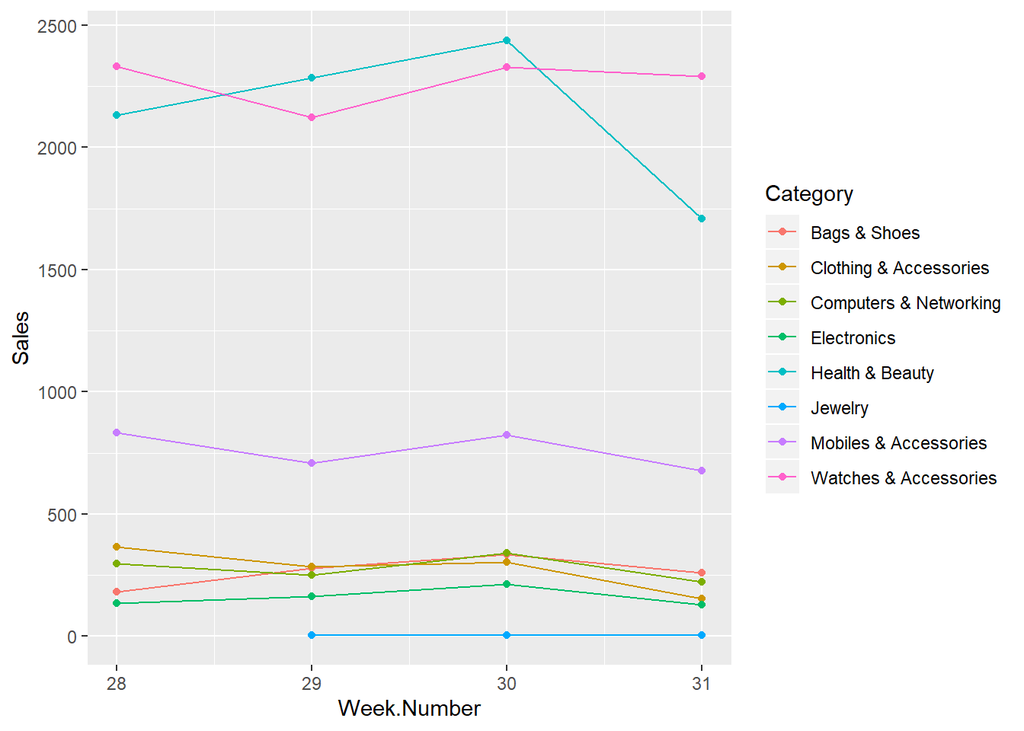

```r
TwoTable <- LCart %>%
      filter(Week.Number > 27) %>%
      group_by(Category, Week.Number) %>%
      summarize(Sales = sum(Quantity.sold), Margin = sum(`Margin.%`/100 * Cost))
g <- ggplot(data = TwoTable)
g + geom_line(aes(x = Week.Number, y = Sales, group = Category, colour = Category)) +
      geom_point(aes(x = Week.Number, y = Sales, group = Category, colour = Category))
```

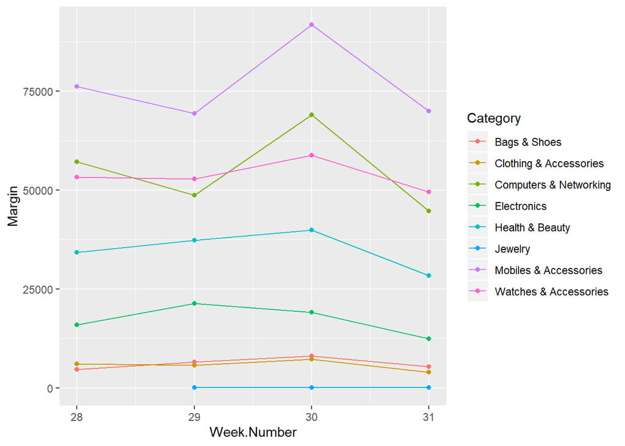

```r
g + geom_line(aes(x = Week.Number, y = Margin, group = Category, colour = Category)) +
      geom_point(aes(x = Week.Number, y = Margin, group = Category, colour = Category))
```

## Task 3

What were the Top 5 selling products in terms of units over the 4 weeks and what were their margin (in % and $)?

```r
LCart <- LCart %>% mutate(Margin = Price - Cost)
Table.Three <- LCart %>%
      filter(Week.Number > 27) %>%
      group_by(Item.Title,Bar.Code) %>%
      summarize(Quantity = sum(Quantity.sold),TotalMargin = sum(Margin), TotalCost = sum(Cost), Margin.Perc = (TotalMargin / TotalCost) * 100) %>%
      arrange(desc(Quantity))
head(as.data.frame(Table.Three), n = 5)
```

```
##                                                   Item.Title     Bar.Code
## 1                                  GUESS PINK FOR WOMEN 75ml 2.724267e+12
## 2   Calvin Klein CK One for Unisex (Eau de Toilette, 200 ML) 2.724269e+12
## 3             Cool Water by Davidoff (125ml Eau de Toilette) 2.724272e+12
## 4 Guess by Marciano for Men by Guess (100ml Eau de Toilette) 2.724273e+12
## 5                                   HTC Rhyme (Plum/English) 2.724272e+12
##   Quantity TotalMargin TotalCost Margin.Perc
## 1      597      8607.4   34429.6    25.00000
## 2      547     10830.2   43320.8    25.00000
## 3      287      5594.6   22378.4    25.00000
## 4      266      4216.0   16864.0    25.00000
## 5      211     12431.9  111887.1    11.11111
```

## Task 4

Which category had the best sales growth over the 4 weeks?

```r
Table.Four <- LCart %>%
      filter(Week.Number > 27) %>%
      group_by(Category, Week.Number) %>%
      summarize(Sales = sum(Price)) %>%
      spread(Week.Number, Sales)
Table.Four$`28` <- replace_na(Table.Four$`28`, 0)
colnames(Table.Four) <- c("Category", "Week1", "Week2", "Week3", "Week4")
Table.Four <- Table.Four %>% group_by(Category) %>% mutate(Sales.Growth = Week4 - Week1, Growth.Margin = Sales.Growth/Week1 * 100) %>% arrange(desc(Sales.Growth))
Table.Four[1,]
```

```
## # A tibble: 1 x 7
## # Groups:   Category [1]
##   Category     Week1 Week2 Week3 Week4 Sales.Growth Growth.Margin
##   <chr>        <dbl> <dbl> <dbl> <dbl>        <dbl>         <dbl>
## 1 Bags & Shoes 29087 40741 50554 33594         4507          15.5
```

## Task 5

Which category had the worst sales growth over the 4 weeks, and what would you do to improve performance?

```r
Table.Four[nrow(Table.Four),]
```

```
## # A tibble: 1 x 7
## # Groups:   Category [1]
##   Category                Week1  Week2  Week3  Week4 Sales.Growth Growth.Margin
##   <chr>                   <dbl>  <dbl>  <dbl>  <dbl>        <dbl>         <dbl>
## 1 Computers & Networking 541834 461610 653582 423734      -118100         -21.8
```

## Task 6

What was the average order value in Electronics over the 4 weeks? How could this be increased?

```r
LCart %>% filter(Week.Number > 27) %>%
      group_by(Order.ID, Category) %>%
      summarize(Order.Value = sum(Price)) %>%
      group_by(Category) %>%
      summarize(Average.Order.Value = mean(Order.Value)) %>%
      filter(Category == "Electronics")
```

```
## # A tibble: 1 x 2
##   Category    Average.Order.Value
##   <chr>                     <dbl>
## 1 Electronics               1245.
```

## Task 7

Identify the Top 10 selling item types by value and units, and propose 3 ideas to grow sales even more on them

```r
Table.Seven <- LCart %>% group_by(Item.Type) %>%
      summarize(Value = sum(Price), Units = sum(Quantity.sold))

#Top 10 selling Item Type by Value
head(Table.Seven %>% arrange(desc(Value)), n = 10)
```

```
## # A tibble: 10 x 3
##    Item.Type               Value Units
##    <chr>                   <dbl> <dbl>
##  1 Mobile Phones         4193041  3719
##  2 Laptops & Notebooks   2591494  1374
##  3 Watches               1652043 11253
##  4 Perfumes & Fragrances 1027846  9952
##  5 Digital Cameras        939249   766
##  6 Eyewear                166912  1313
##  7 Handbags               106014   660
##  8 Shoes                   73517   499
##  9 Dresses                 24314   184
## 10 Backpacks                3330    53
```

```r
#Top 10 selling Item Type by Units
head(Table.Seven %>% arrange(desc(Units)), n = 10)
```

```
## # A tibble: 10 x 3
##    Item.Type               Value Units
##    <chr>                   <dbl> <dbl>
##  1 Watches               1652043 11253
##  2 Perfumes & Fragrances 1027846  9952
##  3 Mobile Phones         4193041  3719
##  4 Laptops & Notebooks   2591494  1374
##  5 Eyewear                166912  1313
##  6 Digital Cameras        939249   766
##  7 Handbags               106014   660
##  8 Shoes                   73517   499
##  9 Dresses                 24314   184
## 10 Backpacks                3330    53
```

## Task 8

List the Top 5 and Bottom 5 sellers by value over the 4 weeks, and show their sales by week

```r
Table.Eight <- LCart %>%
      filter(Week.Number > 27) %>%
      group_by(Seller.Name) %>%
      summarize(Value = sum(Price))

# Top 5 sellers by Value
head(Table.Eight %>% arrange(desc(Value)), n = 5)
```

```
## # A tibble: 5 x 2
##   Seller.Name    Value
##   <chr>          <dbl>
## 1 dod          4800493
## 2 absholding    295353
## 3 DJperfumes    265421
## 4 Mobile-store  264904
## 5 lowestprices  244634
```

```r
# Top 5 sellers by Value
head(Table.Eight %>% arrange(Value), n = 5)
```

```
## # A tibble: 5 x 2
##   Seller.Name    Value
##   <chr>          <dbl>
## 1 harshadachukka    20
## 2 olacbtae          20
## 3 ousha1973         25
## 4 heavy-sahab       36
## 5 mr_rahatali       39
```